# Adjusting the Flight Data by Timezone

Cari Kaufman

February 13, 2015

To run the code for this example you will first need to set the variables *user* and *password* to what I gave you in class.

```r
library(RMySQL)
con = dbConnect(RMySQL::MySQL(), dbname = "ontime",
                host = "radagast.berkeley.edu",
                user = user, password = password)
```

If you want to look at temporal information in the *ontime* table, you need to be aware that the times are all reported relative to the local time zone. For some questions, it would be interesting to translate the times so that they are comparable. For example, we would want two flights, one leaving the west coast at noon and another leaving the east coast at 3pm, to be given the same departure time.

To get the timezone information, we can use the lon/lat information in the *airports* table. Google has an API for obtaining time zone information from lon/lat, but there are limits to the number of requests per minute that we would exceed. Instead, I downloaded shapefiles for the US timezones from http://efele.net/maps/tz/us/. To import the shapefiles into R, I first needed to install the *rgdal* package. (At the moment there aren’t binaries for this package. I followed [these instructions](http://www.janosgyerik.com/installing-rgdal-in-r-on-os-x-mavericks/) to install it on my Mac.) If you want to skip this part and just get the timezone information, you can download the file airportlocs.RData (created below).

```r
library(rgdal)
setwd("~/Dropbox/Work/current/stat222sp15/projects/2-airline/code") # change as needed
tz = readOGR("tz_us", "tz_us") # folder, then file without .shp
```

```
## with 2606 features and 1 fields
## Feature type: wkbPolygon with 2 dimensions
```

```r
class(tz)
```

```
## [1] "SpatialPolygonsDataFrame"
## attr(,"package")
## [1] "sp"
```

```r
names(tz)
```

```
## [1] "TZID"
```

```r
head(tz$TZID)
```

```
## [1] America/Phoenix           America/Phoenix
## [3] America/Phoenix           America/Indiana/Vincennes
## [5] America/Boise             America/Los_Angeles
## 31 Levels: America/Adak America/Anchorage ... Pacific/Honolulu
```

Let’s get the airport location information to overlay over the polygons. However, I only want to get the airports that are listed as origins in the *ontime* table; there are many more than this in the *airports* table.

```r
dbGetQuery(con, "SELECT COUNT(DISTINCT Origin) FROM ontime")
```

```
##   COUNT(DISTINCT Origin)
## 1                    347
```

```r
dbGetQuery(con, "SELECT COUNT(DISTINCT iata) FROM airports")
```

```
##   COUNT(DISTINCT iata)
## 1                 3367
```

```r
query =
"SELECT *
FROM airports
WHERE iata IN (SELECT DISTINCT Origin FROM ontime)"
airportlocs = dbGetQuery(con, query)
```

Let’s plot the airports.

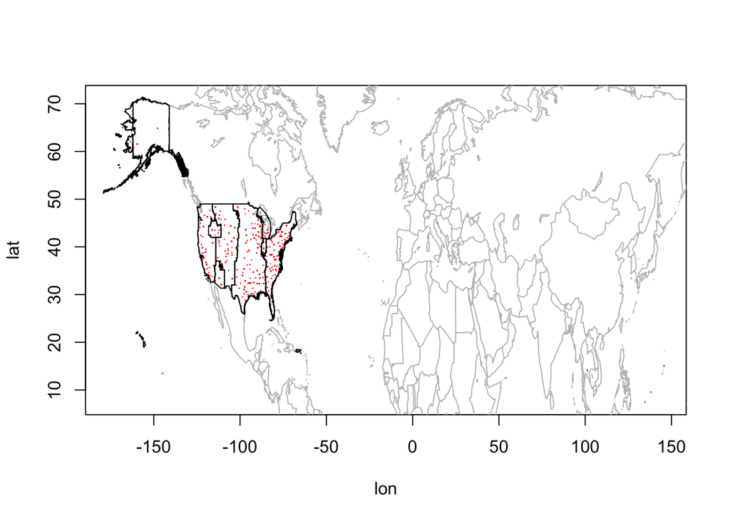

```r
library(maps)
library(sp) # for spatial data classes and plotting
with(airportlocs, plot(lon, lat, pch = ".", col = 2))
map('world', add = TRUE, col = "gray")
plot(tz, add = TRUE)
```

Not all airports are covered by the timezone polygons, so some of them will have missing timezone information.

Now we create a *SpatialPoints* object from the lon/lat data and use the *over* function to get the names of the corresponding polygons; these are the timezones.

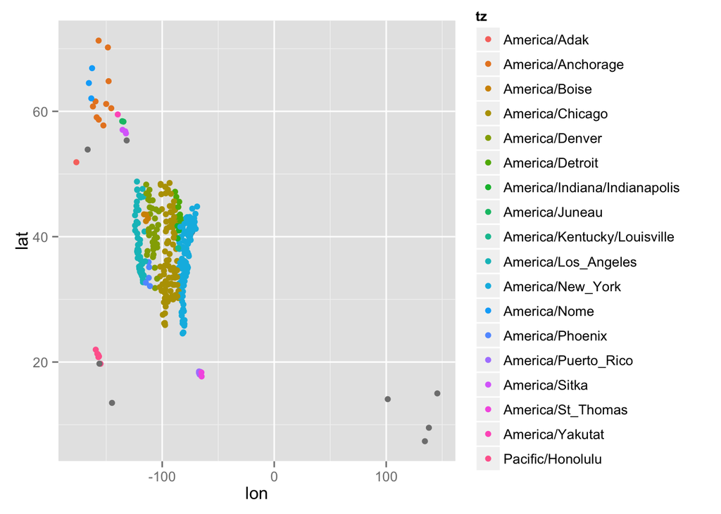

```r
airportsp = SpatialPoints(with(airportlocs, cbind(lon, lat)),
                          proj4string = CRS(proj4string(tz)))
airportlocs$tz = over(airportsp, tz)$TZID
library(ggplot2)
with(airportlocs, qplot(lon, lat, color = tz))
```

```r
save(airportlocs, file = "airportlocs.RData")
```

Now we need to figure out how to adjust for each timezone. This is tricky, because Daylight Saving Time is not followed uniformly across the US, and the period of Daylight Saving Time also changed in 2007. You can find more information about this [here](http://www.timetemperature.com/tzus/time_zone.shtml) and [here](http://www.timetemperature.com/tzus/daylight_saving_time_extended.shtml).

Rather than doing this by hand, I’m going to rely on the timezone implementation within R’s date/time classes. According to the documentation, the function *OlsonNames* gives the ``time-zone names known to the Olson/IANA database on the current system.’’ Luckily for us, this matches the format for the timezone information we have.

```r
help(timezones)
all(is.element(levels(airportlocs$tz), OlsonNames()))
```

```
## [1] TRUE
```

Here’s an example of how you can use this in practice. I’m going to extract the flights for a specific day and then store the times, including the timezone information.

```r
query =
"SELECT *
FROM ontime
WHERE Year = 2008 AND Month = 1 AND DayofMonth = 1"
oneday = dbGetQuery(con, query)
```

Now let’s convert the *DepTime* column to times in POSIXlt format. First extract the hours and minutes. The *hhmm* format is a little non-intuitive, but note that we can manipulate it using modular arithmetic.

```r
hours = oneday$DepTime %/% 100
minutes = oneday$DepTime %% 100
```

Now we get the timezones for each row in the dataframe *oneday*.

```r
index = match(oneday$Origin, airportlocs$iata)
oneday$tz = airportlocs$tz[index]
```

Next, create a character vector with the dates and times. This will be used by the *as.POSIXlt* function.

```r
help(as.POSIXlt)
dates = with(oneday, paste(Year, Month, DayofMonth, sep = "-"))
times = paste(hours, minutes, sep = ":")
datetimes = paste(dates, times)
head(datetimes)
```

```
## [1] "2008-1-1 11:10" "2008-1-1 7:55"  "2008-1-1 19:8"  "2008-1-1 11:55"
## [5] "2008-1-1 13:18" "2008-1-1 11:8"
```

```r
as.POSIXlt(head(datetimes)) # without timezone adjustment
```

```
## [1] "2008-01-01 11:10:00 PST" "2008-01-01 07:55:00 PST"
## [3] "2008-01-01 19:08:00 PST" "2008-01-01 11:55:00 PST"
## [5] "2008-01-01 13:18:00 PST" "2008-01-01 11:08:00 PST"
```

From what I can ascertain, the *as.POSIXlt* can accept timezone information, but with only one timezone at a time.

```r
as.POSIXlt(Sys.time(), tz = "America/Los_Angeles")
```

```
## [1] "2015-02-13 12:36:46 PST"
```

```r
as.POSIXlt(Sys.time(), tz = "America/New_York")
```

```
## [1] "2015-02-13 15:36:46 EST"
```

```r
#as.POSIXlt(rep(Sys.time(), 2), tz = c("America/Los_Angeles", "America/New_York")) # not run; generates an error
```

That’s ok; we’ll just use *lapply* to create a work-around. (I tried using *sapply*, but it didn’t concatenate the results properly. This solution is a bit ugly and slow, but it works.)

```r
wrapper = function(i){
  if(is.na(oneday$tz[i])) return(NA)
  as.POSIXlt(datetimes[i], tz = as.character(oneday$tz[i]))
}
DepTimeTZList = lapply(1:nrow(oneday), wrapper)
DepTimeTZ = do.call(c, DepTimeTZList) # concatenate each element of the list
```

Note that when the concatenation happens, a common timezone is adopted, just as we wanted! Now all the times are directly comparable.

```r
DepTimeTZList[1:3]
```

```
## [[1]]
## [1] "2008-01-01 11:10:00 EST"
##
## [[2]]
## [1] "2008-01-01 07:55:00 CST"
##
## [[3]]
## [1] "2008-01-01 19:08:00 PST"
```

```r
DepTimeTZ[1:3]
```

```
## [1] "2008-01-01 08:10:00 PST" "2008-01-01 05:55:00 PST"
## [3] "2008-01-01 19:08:00 PST"
```

```r
summary(DepTimeTZ) # NAs had missing timezone
```

```
##                  Min.               1st Qu.                Median
## "2007-12-31 20:00:00" "2008-01-01 08:03:00" "2008-01-01 12:06:00"
##                  Mean               3rd Qu.                  Max.
## "2008-01-01 11:52:18" "2008-01-01 16:05:00" "2008-01-02 01:51:00"
##                  NA's
##                 "395"
```